# A longitudinal study of scholars attitudes and behaviors toward open‐access journal publishing - Xia - 2010 - Journal of the American Society for Information Science and Technology - Wiley Online Libr

[Journal of the American Society for Information Science and Technology](https://asistdl.onlinelibrary.wiley.com/journal/15322890)

[Volume 61, Issue 3](https://asistdl.onlinelibrary.wiley.com/toc/15322890/2010/61/3) p. 615-624

Brief Communication

Full Access

# A longitudinal study of scholars attitudes and behaviors toward open‐access journal publishing

[Jingfeng Xia](https://asistdl.onlinelibrary.wiley.com/action/doSearch?ContribAuthorStored=Xia%2C+Jingfeng)

First published: 08 January 2010

https://doi.org/10.1002/asi.21283

Citations: 22

## Abstract

This research applies statistical time series analysis to examine the changing pattern of scholars' attitudes toward open‐access (OA) journal publishing from the early 1990s. By synthesizing survey results in existing studies, this research focuses on representative aspects of the attitudes and behaviors recorded through the years. It finds that although an increase in the publishing and awareness rates of scholars with regard to OA journals has been observed, scholars have been consistently concerned with the low prestige of such journals and their lack of peer review, which is not the case in practice. It is hoped that the findings will provide useful information for the improvement of OA advocacy.

## Introduction

Open access (OA) journal publishing is one of the primary OA publishing formats in practice for delivering research results to the public free of charge. The others are through OA repositories and personal/departmental Web sites. Publishing articles in an OA journal entails a peer‐review process and requires original contributions, identical to traditional scholarly journal publishing, providing necessary control over research quality. OA journal publishing is supported by several different business models which range from an “author‐pay” system to a “toll‐free” system that relies on financial sponsorship from institutions and grant agencies. This unique way of online distribution enables research to be shared more quickly and broadly than that through traditional print publishing.

The origins of OA journal publishing can be traced back to the earliest appearance of electronic journals as experiments in the 1970s (Hiltz & Turoff, 1978; Senders, 1977), although real peer‐reviewed, born‐digital journals did not start until some two decades later. The issuance of *Psycholoquy* in 1989 symbolized the beginning of an OA journal proliferation in the 1990s and has continued since (Harnad, 1990; Suber, 2009). As of Summer 2009, the Directory of Open Access Journals ([www.doaj.org](http://www.doaj.org/)) contained a total of 4,220 OA journal titles, extending to almost all academic fields.

In the beginning, OA journals differed in polices; some provided only abstracts and others full articles, while some delivered via file server and others by e‐mail. Early electronic journals included peer‐reviewed scholarly journals as well as nonscholarly publications such as newsletters. OA journals were sometimes muddled with electronic journals that were issued by commercial publishers with restricted access and print counterparts (Lancaster, 1995; Roes, 1995; Schauder, 1995; Tomney & Burton, 1998). The policies were gradually standardized, allowing OA journals to be readily accessible online to all areas of the world, with a professional‐style design. By 2004, as many as 1,200 journals which consisted of about 5% of the total peer‐reviewed journals in the world were OA journals, so‐called *gold* journals by Harnad et al. (2004). This number has kept growing.

The attitudes and behaviors of scholars as journal‐article authors will directly determine the health of OA journal publishing. Their engagement in OA publishing is based on their acquaintance with OA ideas and practices. It is generally believed that their familiarity has increased over the years; consequently, their involvement also has increased (Morris & Thorn, 2009). OA advocates, practitioners, and other researchers have been careful in monitoring the change of scholars' attitudes and behaviors over their collaborations with OA publishing with the intention of providing valuable insights into how to best improve OA journals and educate scholars about the potentials of OA journal publishing.

One of the earliest surveys on authors' awareness, experience, and concerns for OA possibilities was Schauder's (1994) project among scholars in Australia, the United Kingdom, and the United States for “an assessment of the position of academics in relation to electronic publishing” (p. 73). Since then, surveys on this topic, though with diverse respondents, have been undertaken in every consecutive year until the new millennium (e.g., Anderson, Sack, Krauss, & O'Keefe, 2001; Björk & Turk, 2000; Budd & Connaway, 1997; Lancaster, 1995; McKnight & Price, 1999; Palmer, Speier, Wren, & Hahn, 2000; Shamp, 1992; Speier, Palmer, Wren, & Hahn, 1999; Sweeney, 2000; Tomney & Burton, 1998). These reports presented a clear picture of the early perceptions and practices of digital scholarly communication.

More surveys among authors have been conducted during this decade than that during the previous one. The most well‐known include Swan and Brown's (2002, 2003) project on a group of journal authors world‐wide in late 2001 and early 2002. A year later, the same researchers carried out a comparable survey for similar purposes (Swan & Brown, 2004a, 2004b). Almost concurrently, another report was issued in early 2004 based on an international survey of author opinions among a much larger group of scholars (Rowlands & Nicholas, 2005; Rowlands, Nicholas, & Huntingdon, 2004). Additional examples include large‐scale surveys among international scholars by Swan and Brown (2005), and Hess, Wigand, Mann, and von Walter (2007) and surveys limited to scholar groups targeted either geographically or institutionally by Over, Maiworm, and Schelewsky (2005), Kennan (2007), Ghane (2007), and Austin, Heffernan, and David (2008). Small‐scale surveys also can be found sporadically such as work by Morrison, Waller, and Vézina (2006) and Warlick and Vaughan (2007).

In reading these studies, it becomes evident that their findings are consistent in some areas, but conflicting in others, which may be due to differences in survey times or study populations. For example, while it is apparent from most studies that scholars have become more knowledgeable about OA journal publishing and have expressed their plans to contribute to OA journals in the near future, no concrete evidence has been discovered to illustrate that their willingness had been translated into actions. While the top reason for scholars to choose a journal in which to publish articles has always been the journal's prestige, as reflected by its high impact factor and citation rate, the percentages of their actual working with OA journals has fluctuated from year to year. Furthermore, such observations are scattered, making difficult a fuller understanding of the change of scholars' attitudes. There is no single study synthesizing these isolated surveys, but such a synthesis will be able to highlight scholars' ongoing experience in OA experimentation and reveal how the experience has correlated with the advancement of OA journal publishing throughout the years.

This research will apply a longitudinal approach to synthesize previous observations of journal authors' opinions and examine possible trends of attitude and behavioral changes of scholars. A longitudinal study is a correlational research appropriate for capturing changes through time (Veldman, 1997). The concentration of the synthesis and analysis will be on scholars' understanding of OA journal publishing and willingness to contribute to such journals. Their reasons to publish as well as not to publish in the journals will be compared across surveys from different dates to see if scholars' views of OA follow a chronological pattern. If time is meaningful for OA advocacy, there should be a steady increase in scholars' awareness and motivation toward OA journal publishing during a multiyear interval.

## Methodology

### Data Selection

Literature was carefully reviewed to locate published material on this topic. There are numerous studies focusing on the perceptions and experience of scholars from a publisher's, editor's, or reader's perspective; and users' experience is particularly popular in the literature (e.g., Tenopir & King, 2008). Although these studies have provided useful information, few of them contain piecemeal data of interest to our analysis. Another concern in data selection was the diverse policies of electronic journal publishing in the early 1990s, when varied definitions of “electronic journals” were applied. Some studies, though using the same term, discussed issues other than electronic journals for OA; these were excluded from the analysis.

To carry out a quantitative analysis, studies that did not provide statistics were not included in the list of analyzed sources, although they were consulted to assist with the analysis for the purposes of understanding and interpretation. Interviews generally belong to this category. In contrast, lengthy reports based on scientific surveys were the best sources, and journal articles and concise slide presentations served as complements.

Data were searched through the following channels:

- General search engines, mainly Google and Google Scholar
- General literature databases such as Academic Search Premier and Social Science Research Network
- Literature databases in the field of library and information science, such as Library Literature and Information Science Full Text
- Citation references of relevant studies, the primary method of expanding the list of important surveys on the topic
- Scholarly electronic‐publishing bibliographies such as one compiled by Charles W. Bailey (2009) and reviewed annually
- Contacting authors of certain important surveys.

It was fortunate that a group of extensive reports representing systematically designed surveys existed and had been collected for each year since 1991 until now. For some years in the early 1990s, only one report could be identified to represent a year. We had no choice but to incorporate them into our analysis. For the most recent years, though, there were multiple reports discovered for each year, requiring the development of a data‐selection strategy through which the most suitable surveys could be identified.

The *Cochrane systematic review* principles were adopted to guide data selection (Cooper & Hedges, 1994; Higgins & Green, 2008). Although the Cochrane review format primarily aims to help researchers evaluate and prepare evidence for healthcare‐related studies, its standards on synthesis of the available evidence on a given topic are applicable to research in many other scientific fields. Basically, the Cochrane review for eligibility criteria emphasizes the assessment of a set of prespecifications to seek all rigorous candidates for statistical analyses. The prespecifications may include, but are not limited to, the evaluation of the participants, interventions, and comparisons in studies, each of which is discussed next.

*Participants* refers to people or a population of studies and focuses on the sufficiency and broadness of any study population so that meaningful answers can be obtained. Characters of study populations, such as age, sex, and educational status, should be examined to determine special groups of interest.

Many of the surveys that were discovered were carried out among scholars on a world‐wide level. According to the demographics described in these reports, the majority of respondents were from Europe, North America, and Australia and were clustered in higher educational institutions. Thus, their views were mainly Western‐oriented and academic. Another group of projects limited their surveys to a particular country (e.g., Australia, Canada, Germany, or the United States) or even a subgroup (e.g., senior scholars, faculty in one university system, or researchers sponsored by the German Research Foundation). Although the incorporation of the subgroups into our analysis was minimized whenever possible, the comparison of single‐country surveys with international surveys was inevitable. Several reasons made the comparisons dependable: (a) The international surveys selected in this analysis consisted of scholar populations in the countries where the single‐country surveys were taken; (b) a simple random‐sampling strategy (or other random‐sampling strategies) was applied throughout with a few exceptions, thereby reducing biases; (c) almost all sample sizes were large enough (many had more than 1,000 respondents) to minimize possible errors; and (d) all findings incorporated into this analysis were “generic” ones that tended to reflect the very basic aspects of scholars' attitudes and behaviors, and any questions local to individual surveys were excluded.

*Interventions* specifies the interventions of interest and the interventions against which these will be compared. In healthcare settings, there may be complex interventions in review, and the studies usually use experimental formats. This study only took the simplest form and concentrated on what was the most applicable representation of “intervention” for the analysis: time as the independent variable.

This research applies statistical *time‐series analysis* to the data collected and synthesized. Time‐series analysis is modeled to handle consecutive measurements taken at “equally spaced” time intervals, although our data do not represent perfect, “equally spaced” time intervals. “Year” is the interval unit of this analysis, although some surveys were taken in the beginning of a year whereas others were in the middle or the end of a year. In addition, there are surveys spanning 2 years from the beginning of the projects to their conclusion. There are no studies which included adequate data to represent seasons or even months, unfortunately, and assigning reports to characterize a year is somewhat artificial. Nonetheless, this study accepts this irregularity because attitude changes could not be as sensitive as to months when there were no intentionally designed intensive treatments involved, except for the time as a process of treatment. Yearly measurements were considered to be adequate. Here, the *year* representation refers to the time for the actual conduct of a survey rather than the time for any pilot survey or for publication which could significantly lag behind a survey.

*Comparisons* refers to the fact that although a Cochrane review typically does not include outcomes as part of the assessment criteria, some reviews do legitimately restrict eligibility to specific outcomes based on the very nature of individual studies.

In our data, all survey questionnaires were organized in different ways, which made the data normalization a challenging job. Questions were not only structured and verbalized differently but the measurement mode also varied from survey to survey. For example, a “yes/no” category‐type answer might provide less meaningful information than would a 7‐scale Likert selection for a quantitative analysis, and aggregated data could impede statistical breakdown of discrete values. Furthermore, content coverage in some reports was wider than in others, and content focus could have shifted considerably from one survey to the others, making the initial evaluations discouraging. This research finally adopted the solution of selecting those questions that could deliver answers about the very basic aspects of scholars' attitudes and behaviors and by downscaling the data to ratings and percentages. We hoped that these decisions would be able to keep at a minimum the problems caused by the content discrepancy.

A list of surveys was eventually identified that chronologically represented different stages of OA journal publishing (see Table 1). Inevitably, data for certain variable(s) were totally unavailable for a single year; however, this was relatively uncommon and was handled later in the statistical‐analysis stage.

Table 1. Main sources selected for the analysis, where surveys in parentheses are the secondary sources.

| Year represented | Survey time | Source | Sample size | Population |
| --- | --- | --- | --- | --- |
| 1991 | 1992 | Shamp, 1992 | 81 | USA |
| 1992 | 1992 | Schauder, 1994 | 582 | Australia, United Kingdom, USA |
| 1993 | 1993–1994 | Lancaster, 1995 | 150 | USA |
| 1994 | 1994 | Butler, 1995 | 481 | Multiple countries |
| 1995 | 1995 | Budd & Connaway, 1997 | 651 | USA |
| 1996 | 1996 | Tomney & Burton, 1998 | 147 | United Kingdom |
| 1997 | 1997 | Palmer et al., 2000; Speier et al., 1999 | 300 | USA |
| 1998 | 1998 | McKnight & Price, 1999 | 537 | United Kingdom |
| 1999 | 1999 | Swan & Brown, 1999 | 2,500 | Multiple countries |
| 2000 | 2000 | Bjork & Turk, 2000 | 236 | Multiple countries |
|  | 2000 | (Sweeney, 2000) | 62 | Florida State University System |
| 2001 | 2001 | Anderson et al., 2001 | 104 | Multiple countries |
| 2002 | 2001–2002 | Swan & Brown, 2003 | 1,246 | Multiple countries |
| 2003 | 2003–2004 | Rowlands et al., 2004 | 3,787 | Multiple countries |
|  | 2003–2004 | (Swan & Brown, 2004a) | 311 | Multiple countries |
| 2004 | 2004 | (Over et al., 2005) | 1,028 | Germany |
|  | 2004 | Swan & Brown, 2005 | 1,296 | Multiple countries |
| 2005 | 2005 | Rowlands & Nicholas, 2005 | 5,513 | Multiple countries |
|  | 2005–2006 | (King et al., 2006) | 49 | University of California, Berkeley |
| 2006 | 2006 | (Morrison et al., 2006) | 150 | Canada |
|  | 2006 | (Kennan, 2007) | 202 | Australia |
|  | 2006 | Hess et al., 2007 | 688 | Multiple countries |
|  | 2006 | (UC, 2007) | 1,118 | USA |
| 2007 | 2007 | Austin et al., 2008 | 509 | Australia |
|  | 2007 | (Brown & Swan, 2007) | 2,250 | United Kingdom |
| 2008 | 2008 | Morris & Thorn, 2009 | 1,368 | Multiple countries |

### Data Normalization

Except for several reports that were undertaken by the same researchers at different times, all other works were individually designed, conducted, analyzed, and written. Even the former studies contained differences in their scope, population, and sample size. Thus, tremendous effort was made to select and normalize the data.

Data normalization is a process that allows underlying characteristics of the outcome datasets to be compared. There are various normalization strategies. Normalization in statistics commonly involves the standardization of different data scales and the recategorization of research questions and answers. This analysis followed statistical normalization principles and focused on several research questions pertaining to the topics of interest.

Table 2 shows the areas of interest for this analysis. These areas are *awareness*, *action*, and *attitude*, each of which is supported by several questions extracted from the original surveys. The awareness variable was measured by the question “Do you know the existence of an OA journal in your field?” which was expressed differently in individual reports. The answers in the reports were designed to be either “yes/no” pairs or a Likert scale. When scaled measures were taken, the most frequent terms used included, among others, “very high” and “high” or “a lot” and “a little.” In the normalization step, both “very high” and “high” (or “a lot” and “a little”) were modified into a “yes” answer because this analysis is only interested in whether scholars know the practice of OA journal publishing, not their degree of familiarity.

Table 2. Areas of interest for analysis.

| Construct formed | Question normalized | Answers selected | Scale adjusted |
| --- | --- | --- | --- |
| Awareness | Do you know the existence of an OA journal in your field? | Yes/No | Percent |
| Action | Did you publish in any OA journal in the past? | Yes/No | Percent |
|  | Will you plan to publish in OA journals in the near future? | Yes/No | Percent |
| Attitude | What are your reasons to publish in journals in general? | To share with peers | Ranking |
|  |  | To gain reputation | Ranking |
|  | What are your reasons to publish in OA journals? | Free access | Ranking |
|  |  | Publishing speed | Ranking |
|  | What are your reasons not to publish in OA journals? | Low prestige/impact factor | Ranking |
|  |  | Lack of peer review | Ranking |

- OA=open access.

The action variable was examined through two questions: “Did you publish in any OA journal in the past?” and “Will you plan to publish in OA journals in the near future?” For the first question, the answer in the original reports was either “yes/no” or was designed to record the actual number of articles in OA journals. For example, the respondents might be asked to select among having published one, two, or three or more articles. Again, it is irrelevant to this analysis to know how many OA articles have been published. The answers to the second question in several original reports identified the respondents' planned publishing time for OA articles: the next 6 months, 12 months, and so on. Likewise, this time specification is irrelevant. In this analysis, publishing action was recorded as “yes” for any amount already published and for any intention to publish in the future.

This selection of sample variables from a pool of possible answers seems to expose the research to threats of internal validity; that is, leaving other variables unmeasured. The questions selected for the areas of interest in the research represented only a small fraction of most surveys' content; however, they were the most descriptive ones to sufficiently reflect scholars' attitudes and behaviors for the purpose of this analysis. They also constituted the core questions that were covered in almost all the surveys, which made a cross‐study comparison feasible. These two reasons were ranked at the top over nearly 90% of the surveys and through the time span of 20 years. In addition, the explanations sought by this analysis are not exclusive. Altogether, this means that the selected definitions and concepts give a reasonable view of the subject, and allow aggregated analysis, which improves overall validity.

The sample sizes of the individual surveys were all different. No effort was made in this analysis to weigh each into a combined average. Instead, the analysis relied on the percentages of the original measures to make necessary comparisons to maintain data integrity.

There are some limitations to this analysis. The heterogeneity of the content of these surveys restricted the ability to explore the differences in scholars' attitudes across various academic fields, such as sciences versus social sciences, which would be valuable information to distinguish disciplinary cultures in information sharing. Unfortunately, relevant data and reasonable analyses were missing from too many surveys. This is a drawback of some longitudinal studies that rely on historical data, especially when a longitudinal study is constrained to a short time span, as this analysis was. Likewise, this analysis was not able to make comparisons among scholars of different geographical locations, another important factor for contributing to the understanding of the whole picture. The differences of a scholar's academic rank also were not included due to the available data; thus, we were not able to distinguish between junior and senior scholars and establish correlations, if any, between OA development and scholars' positions in OA.

### Data Analysis

Time‐series analysis was selected to statistically make the comparisons through time because this method is applicable to a collection of quantitative measurements taken at regular intervals through repeated surveys. For our analysis, the interval was set to *year* and started from 1991. Additionally, because time‐series analysis assumes an internal structure (e.g., trends) in interval data points, it is appropriate for modeling changes in scholars' attitudes and behaviors as a longitudinal study.

With time‐series analysis, there are many statistical models designed for various data types and analytical purposes. The most suitable model for this analysis is exponential smoothing because of its advantages in weighing heavily the most recent observations for forecasting and in handling trends with no seasonality. Exponential smoothing also has an advantage over the Box–Jenkins time‐series analysis model, which requires 50 or more successive values. Here, the double (or Holt) exponential smoothing scheme was employed to model linear temporal data.

What exponential smoothing does is to assign exponentially decreased weights as the observations in a time series get older. To determine the weights, smoothing parameters are to be determined or estimated. For double exponential smoothing, two such parameters are required with the symbols α and γ, which also are known as the smoothing constants. The normal way of determining their values is through nonlinear optimization techniques such as the Marquardt Algorithm. The basic principle is that these values should be selected to result in the lowest possible *MSE* when comparing the original series to the forecasts.

In general, time‐series analysis provides a mechanism to help understand a sequence of data points by illustrating the underlying context of the data and by relying on observed values to predict future values. Upon appropriate examination, patterns of observed time‐series data can be identified, which in turn can be more or less formally interpreted and integrated with other types of data and analysis such as qualitative descriptions. Regardless of the extent of understanding and the validity of interpretation of the phenomenon by the time‐series analysis, it is at least possible to extrapolate the identified pattern to forecast future events.

SPSS Version 17.0 was used to perform the time‐series analysis. Before applying its forecasting function for the exponential smoothing, data were readjusted by running the “replacing missing values” command (that implements the *MLE* principles) to fill in missing values for some spots in the series; this consisted of around 15% of the total points. Time‐series analysis does not allow missing values within a series. Data absent at the beginning or end of the series were disregarded, however, because hypothetically they would not affect the time‐series analysis. For forecasting, the 95% confidence interval was applied.

## Results

### Awareness

Are scholars aware of OA journal publishing? The percentage of respondents answering “no” to this question has declined steadily through the years. Pearson's correlation coefficients of the observations on this variable help verify an obvious trend of decrease (*r*=−0.96). In time‐series analysis, the reduction in unawareness rate started from the mid‐1990s and will continue beyond the series (Figure 1). The rate was as high as around 50% at the beginning of the series, but dropped to below 15% by 2007, probably indicating that the majority of, if not all, academic disciplines now have some OA electronic journals and that the majority of, if not all, scholars know of this new publishing channel.

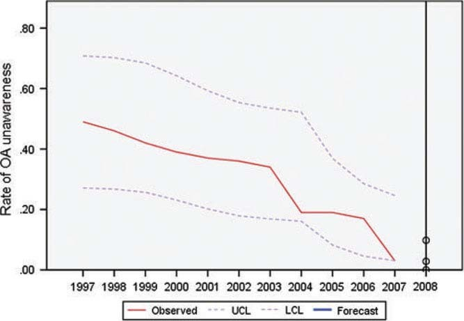

**Figure 1**

A chronological change of open‐access unawareness rate.

Here, *awareness* refers to the fact that scholars know of the existence of OA journal publishing; however, it does not describe the degree of awareness. In fact, many scholars surveyed were not able to tell the difference between an OA journal and a subscription‐based electronic journal; some of them may not have realized the existence of OA. A 2008 survey by Morris and Thorn (2009) found that “not all were clear about what OA journals actually were” (p. 223). Necessary clarifications on scholars' understanding of OA journal functions have not been the focus of the majority of the surveys; thus, no such data have been incorporated into the time‐series analysis.

### Action

Figure 2 shows a trend of gradual increase in the number of scholars actually publishing in OA journals over the years. This may reflect a growing number of OA journals available to scholars in many academic fields and an increasing awareness of such journals by scholars. In contrast, also note that although the rate started very low in the mid‐1990s, it still did not reach a high level by the end of the sequence of observations, even with a detectable, continual rise. This may indicate a relative hesitation among scholars for making contributions to OA journal publishing.

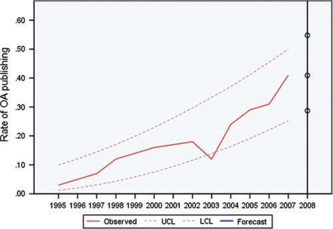

**Figure 2**

A chronological change of open‐access publishing rate.

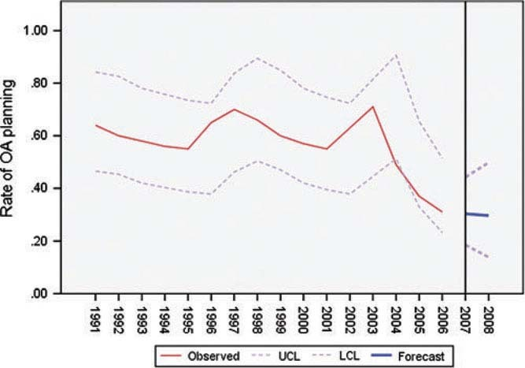

**Figure 3**

A chronological change of open‐access publication planning rate.

### Attitude

What are the reasons that drive scholars to publish their articles in academic journals in general? This question was selected for the purpose of making comparisons to the reasons to publish in OA journals in particular. Respondents selected many reasons for the former question, and might have selected more had they not been restricted by a list of answers provided by the surveyors. The most important reason in most surveys was to communicate with peer researchers, particularly peers in the same interest area. Readership was, therefore, the primary consideration for publication. Respondents also liked to gain personal reputation through publishing research results, a reason that was second in importance. No matter to which academic discipline the scholars belonged, they shared the same interests (see Davies & Greenwood, 2004). When temporal data are examined, a uniformity of the ranking of the reasons is exhibited (Figures 4a and 4b); namely, there is no obvious change of scholars' attitudes over the time span of this research, and the trend will most likely continue.

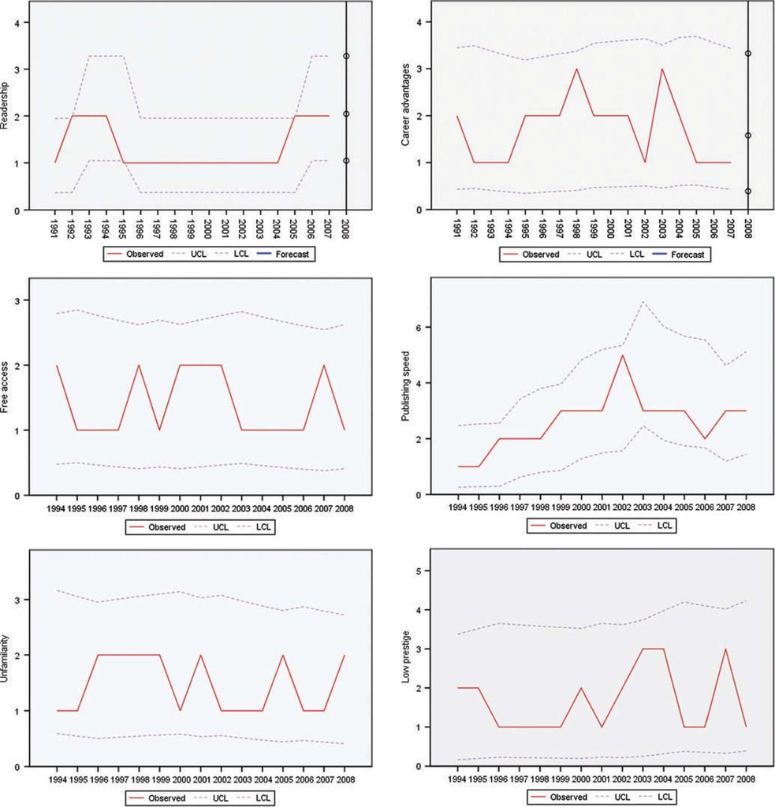

**Figure 4**

Change of scholars' recognition of open‐access readership.

An equally important concern of scholars about OA journal publishing is the prestige of the OA journals. It has been commonly believed by scholars that OA journals have a low impact factor and receive low citation rates. This misunderstanding of low citations neglects the fact that OA publishing has created a dramatic impact on citation patterns (Harnad & Brody, 2004; Kurtz et al., 2004; Lawrence, 2001; Odlyzko, 2002). Among other changes, an obvious increase in the citation counts of OA publications has been discovered. A more recent study published in *Science* by Evans (2008) confirmed this discovery (p. 398).

In addition, peer review is typically not connected with this innovative publishing model. In questioning the quality of OA journals, scholars are afraid that their scholarly careers can be negatively affected if they keep publishing articles in these journals, which can directly influence their promotion and tenure (see discussion in Cronin & Overfelt, 1995). Although scholars' concerns about this point have fluctuated throughout the years, there has been no large change observed in this analysis (Figure 4f).

Note that there are many other answers through which scholars' attitudes toward OA journal publishing can be measured. Sometimes other reasons were weighed close to, if not equally or even more frequently than, the reasons examined earlier in the original reports. This selection of two reasons per answer was set for the purpose of simplifying the analysis. Yet, it also is true that these reasons were not only more frequently picked by respondents but also represented the reasons that overlapped in most surveys. Some other reasons may have been individualized in particular survey questionnaires and were not uniformly available throughout the surveys.

## Conclusion

In this research, time‐series analysis has demonstrated its strengths for modeling changes observed over regular time intervals. Although the surveys used in the analysis are scattered and not in coherent streams or sequential extensions, this study has been fortunate to assemble, through data selection and normalization, a group of survey results representing each year since the early 1990s. It is an appropriate fit for surveys covering the 20‐year time to match the life span of the OA movement and OA journal publishing. The richness of the investigations reflects people's ongoing interest in OA. We will expect to read more surveys on scholars' attitudes and behaviors about OA publishing in the future as a result of increases in the involvement of policy makers and young scholars in OA. It is hoped that future studies of this type can learn from the design of previous surveys so that standard survey instruments can be set to generate evidence to reveal the trajectory of OA development with reference to the changes of scholars' cooperation.

These findings may help alert OA advocates and managers of the weaknesses in their previous efforts and indicate possible areas to improve in the future. Although variations in scholars' attitudes and behaviors have been noticed by researchers, longitudinal research on historical data has allowed us to view them in a systematic way, and a forecasting study has provided us with useful tools to see the direction of the enterprise.

## Acknowledgments

I am grateful to Blaise Cronin, Marilyn Irwin, and Katie Nakanishi for their help in the writing of this article, and to the anonymous referees for their useful comments. I particularly thank Rachel Applegate for her valuable comments on the early drafts.

## Citing Literature

March 2010

Pages 615-624